# Modeling and prediction for movies

### Setup

The objective of this project to create a linear regression model that predicts the popularity of a movie. The given data has been collected from Rotten Tomatoes and IMDb which are popular review-aggregator and database information platforms for films and television.

### Load packages

```r
library(ggplot2)
library(dplyr)
library(statsr)
library(gridExtra)
library(GGally)
library(car)
```

### Load data

```r
load("movies.Rdata")
str(movies)
```

```
## Classes 'tbl_df', 'tbl' and 'data.frame':    651 obs. of  32 variables:
##  $ title           : chr  "Filly Brown" "The Dish" "Waiting for Guffman" "The Age of Innocence" ...
##  $ title_type      : Factor w/ 3 levels "Documentary",..: 2 2 2 2 2 1 2 2 1 2 ...
##  $ genre           : Factor w/ 11 levels "Action & Adventure",..: 6 6 4 6 7 5 6 6 5 6 ...
##  $ runtime         : num  80 101 84 139 90 78 142 93 88 119 ...
##  $ mpaa_rating     : Factor w/ 6 levels "G","NC-17","PG",..: 5 4 5 3 5 6 4 5 6 6 ...
##  $ studio          : Factor w/ 211 levels "20th Century Fox",..: 91 202 167 34 13 163 147 118 88 84 ...
##  $ thtr_rel_year   : num  2013 2001 1996 1993 2004 ...
##  $ thtr_rel_month  : num  4 3 8 10 9 1 1 11 9 3 ...
##  $ thtr_rel_day    : num  19 14 21 1 10 15 1 8 7 2 ...
##  $ dvd_rel_year    : num  2013 2001 2001 2001 2005 ...
##  $ dvd_rel_month   : num  7 8 8 11 4 4 2 3 1 8 ...
##  $ dvd_rel_day     : num  30 28 21 6 19 20 18 2 21 14 ...
##  $ imdb_rating     : num  5.5 7.3 7.6 7.2 5.1 7.8 7.2 5.5 7.5 6.6 ...
##  $ imdb_num_votes  : int  899 12285 22381 35096 2386 333 5016 2272 880 12496 ...
```

[output cut: 18 more lines]

```r
# Removing all NA rows
movies <- na.omit(movies)
```

## Part 1: Data

The data consists of 651 observations with 32 variables. The data has been randomly sampled from thousands of films and there is no random assignment. This is an observational study so the findings are generalizable but not causal in any way.

## Part 2: Research question

As a person who regularly uses IMDb and Rotten Tomatoes for an experts’ opinion before watching a new movie, I would like to know what makes a movie popular. Being a regular user, I know that ratings and scores are surely good ways to find out how good a movie is but ‘number of votes received’ is a better indicator a movie’s popularity. So is there a relationship between number of votes on IMDb(imdb_num_votes) and the other collected variables like genre, rating, runtime, certification, awards, release time, cast and crew, etc.?

## Part 3: Exploratory data analysis

Exploratory data analysis has been done for selecting valuable features and for better understanding the data. Features showing high variability and interpretability will be selected.

- Features like title,imdb_url and rt_url are obviously unique and not useful at all.

```r
length(unique(movies$studio))
## [1] 202
length(unique(movies$director))
## [1] 504
length(unique(movies$actor1))
## [1] 461
length(unique(movies$actor2))
## [1] 550
length(unique(movies$actor3))
## [1] 580
length(unique(movies$actor4))
## [1] 590
length(unique(movies$actor5))
## [1] 598
```

- All the above features are **high cardinality features** as the number of unique values are close to total number of observations. So, they are not useful for the model.

[figure not shown]

```r
p1 <- ggplot(movies, aes(x=title_type, y=imdb_num_votes, fill=title_type)) +
    geom_boxplot(alpha=0.3) +
    theme(legend.position="none")
p2 <- ggplot(movies, aes(x=mpaa_rating, y=imdb_num_votes, fill=mpaa_rating)) +
    geom_boxplot(alpha=0.3) +
    theme(legend.position="none")
grid.arrange(p1, p2, nrow = 1, ncol = 2, top="Distribution of IMDb voter count for different title types and mpaa ratings")
```

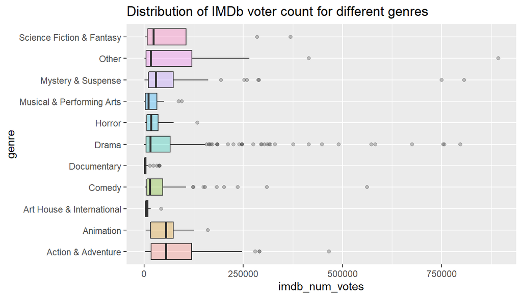

```r
ggplot(movies, aes(x=genre, y=imdb_num_votes, fill=genre)) +
    geom_boxplot(alpha=0.3) +
    theme(legend.position="none") +
    ggtitle("Distribution of IMDb voter count for different genres") +
    coord_flip()
```

- Action & adventure movies are most likely to get more votes but drama movies have many outliers. Documentaries and art house movies don’t get much attention.

[figure not shown]

```r
p1 <- ggplot(movies, aes(x=factor(thtr_rel_year), y=imdb_num_votes), fill=factor(thtr_rel_year)) +
  geom_boxplot(alpha=0.3) +
  theme(legend.position="none") +
  coord_flip()
p2 <- ggplot(movies, aes(x=factor(dvd_rel_year), y=imdb_num_votes), fill=factor(dvd_rel_year)) +
  geom_boxplot(alpha=0.3) +
  theme(legend.position="none") +
  coord_flip()
p3 <- ggplot(movies, aes(x=factor(thtr_rel_month), y=imdb_num_votes), fill=factor(thtr_rel_month)) +
  geom_boxplot(alpha=0.3) +
  theme(legend.position="none") +
  coord_flip()
p4 <- ggplot(movies, aes(x=factor(dvd_rel_month), y=imdb_num_votes), fill=factor(dvd_rel_month)) +
  geom_boxplot(alpha=0.3) +
  theme(legend.position="none") +
  coord_flip()
p5 <- ggplot(movies, aes(x=factor(thtr_rel_day), y=imdb_num_votes), fill=factor(thtr_rel_day)) +
  geom_boxplot(alpha=0.3) +
  theme(legend.position="none") +
  coord_flip()
p6<- ggplot(movies, aes(x=factor(dvd_rel_day), y=imdb_num_votes), fill=factor(dvd_rel_day)) +
  geom_boxplot(alpha=0.3) +
  theme(legend.position="none") +
  coord_flip()
grid.arrange(p1, p2, p3, p4, p5, p6, nrow = 3, ncol = 2, top="Distribution of IMDb voter count across DVD and theatre release time")
```

- DVD and theatre releases of recent years are more likely to garner more votes. People don’t seem to vote much for movies released in September, whether released on DVD or in theatres. Aside from thtr_rel_year, none of other features seem to follow any trend or give polarising insights regarding voting.

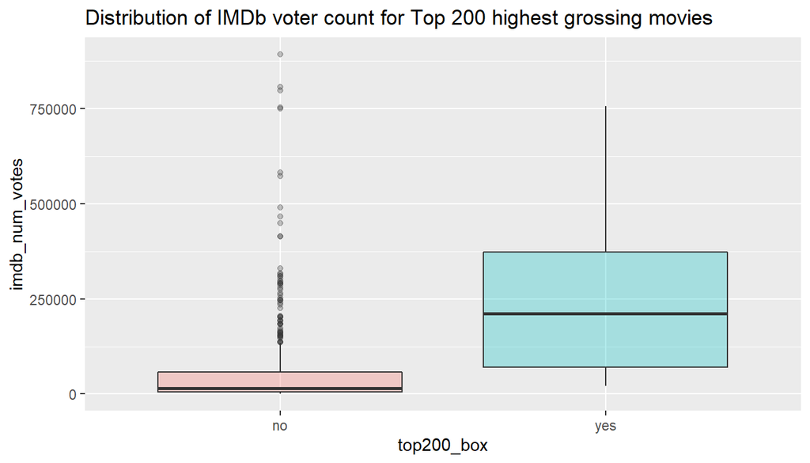

```r
ggplot(movies, aes(x=top200_box, y=imdb_num_votes, fill=top200_box)) +
    geom_boxplot(alpha=0.3) +
    ggtitle("Distribution of IMDb voter count for Top 200 highest grossing movies") +
    theme(legend.position="none")
```

- The striking difference in the distribution of movies based on them being in the top 200 boxofficemojo list indicates movies in this exclusive list are likely to get more votes.

[figure not shown]

```r
p1 <- ggplot(movies, aes(x=best_pic_nom, y=imdb_num_votes, fill=best_pic_nom)) +
    geom_boxplot(alpha=0.3) +
    theme(legend.position="none")
p2 <- ggplot(movies, aes(x=best_pic_win, y=imdb_num_votes, fill=best_pic_win)) +
    geom_boxplot(alpha=0.3) +
    theme(legend.position="none")
p3 <- ggplot(movies, aes(x=best_actor_win, y=imdb_num_votes, fill=best_actor_win)) +
    geom_boxplot(alpha=0.3) +
    theme(legend.position="none")
p4 <- ggplot(movies, aes(x=best_actress_win, y=imdb_num_votes, fill=best_actress_win)) +
    geom_boxplot(alpha=0.3) +
    theme(legend.position="none")
p5 <- ggplot(movies, aes(x=best_dir_win, y=imdb_num_votes, fill=best_dir_win)) +
    geom_boxplot(alpha=0.3) +
    theme(legend.position="none")
grid.arrange(p1, p2, p3, p4, p5, nrow = 1, ncol = 5, top="Distribution of IMDb voter count for different oscar wins")
```

- Films that get nominated or win the oscar are likely to get more votes. Films whose directors are winning oscars are also likely to get more votes.

[figure not shown]

```r
p1 <- ggplot(movies, aes(x=critics_score, y=imdb_num_votes)) +
    geom_point()
p2 <- ggplot(movies, aes(x=audience_score, y=imdb_num_votes)) +
    geom_point()
p3 <- ggplot(movies, aes(x=imdb_rating, y=imdb_num_votes)) +
    geom_point()
grid.arrange(p1, p2, p3, nrow = 1, ncol = 3, top="Distribution of IMDb voter count for scores and ratings")
```

- Higher approval from audience and critics is likely to result in more votes for a movie.

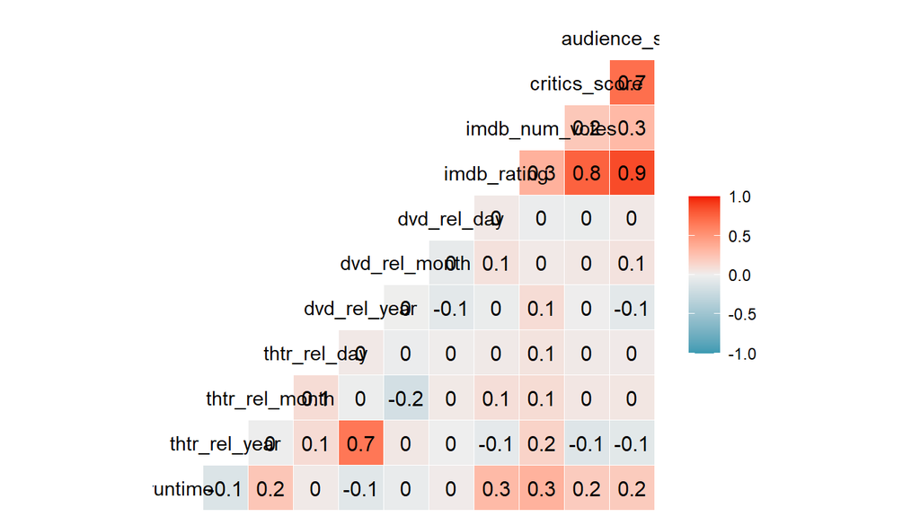

```r
#everything is used for covariances with missing values.
#Pearson is used for indicating corr coefficient
ggcorr(movies, method = c("everything", "pearson"),label=TRUE)
```

- The above correlation heatmap high correlation among audience_score,critics_score and imdb_rating. As this is a collinearity condition, audience_score and critics_score will be dropped in favor imdb_rating. On similar account, dvd_rel_year will be dropped due to high correlation with thtr_rel_year.

## For modeling, the following features will be used:

```r
movies2 <- movies %>%
  select(title_type,genre,runtime,mpaa_rating,top200_box,thtr_rel_year,imdb_rating,imdb_num_votes,best_pic_nom,best_pic_win,best_dir_win,thtr_rel_month,thtr_rel_day)
str(movies2)
```

```
## Classes 'tbl_df', 'tbl' and 'data.frame':    619 obs. of  13 variables:
##  $ title_type    : Factor w/ 3 levels "Documentary",..: 2 2 2 2 2 2 2 1 2 2 ...
##  $ genre         : Factor w/ 11 levels "Action & Adventure",..: 6 6 4 6 7 6 6 5 6 1 ...
##  $ runtime       : num  80 101 84 139 90 142 93 88 119 127 ...
##  $ mpaa_rating   : Factor w/ 6 levels "G","NC-17","PG",..: 5 4 5 3 5 4 5 6 6 3 ...
##  $ top200_box    : Factor w/ 2 levels "no","yes": 1 1 1 1 1 1 1 1 1 2 ...
##  $ thtr_rel_year : num  2013 2001 1996 1993 2004 ...
##  $ imdb_rating   : num  5.5 7.3 7.6 7.2 5.1 7.2 5.5 7.5 6.6 6.8 ...
##  $ imdb_num_votes: int  899 12285 22381 35096 2386 5016 2272 880 12496 71979 ...
##  $ best_pic_nom  : Factor w/ 2 levels "no","yes": 1 1 1 1 1 1 1 1 1 1 ...
##  $ best_pic_win  : Factor w/ 2 levels "no","yes": 1 1 1 1 1 1 1 1 1 1 ...
##  $ best_dir_win  : Factor w/ 2 levels "no","yes": 1 1 1 2 1 1 1 1 1 1 ...
##  $ thtr_rel_month: num  4 3 8 10 9 1 11 9 3 6 ...
##  $ thtr_rel_day  : num  19 14 21 1 10 1 8 7 2 19 ...
##  - attr(*, "na.action")= 'omit' Named int  6 25 94 100 131 172 175 184 198 207 ...
##   ..- attr(*, "names")= chr  "6" "25" "94" "100" ...
```

## Part 4: Modeling

For modeling, a multiple regression model with backwards elimination will be used where features will be removed based on high p-values.

First, we will fit all the selected features.

```r
all_feats <- lm(imdb_num_votes~title_type+genre+runtime+mpaa_rating+top200_box+thtr_rel_year+imdb_rating+best_pic_nom+best_pic_win+best_dir_win,data=movies2)
summary(all_feats)
```

```
##
## Call:
## lm(formula = imdb_num_votes ~ title_type + genre + runtime +
##     mpaa_rating + top200_box + thtr_rel_year + imdb_rating +
##     best_pic_nom + best_pic_win + best_dir_win, data = movies2)
##
## Residuals:
##     Min      1Q  Median      3Q     Max
## -255487  -45620  -10350   22944  644173
##
## Coefficients:
##                                  Estimate Std. Error t value Pr(>|t|)
## (Intercept)                    -5908214.0   720996.6  -8.195 1.55e-15 ***
## title_typeFeature Film            44546.3    34883.8   1.277  0.20210
## title_typeTV Movie                21657.7    55824.6   0.388  0.69818
## genreAnimation                     9446.0    36005.9   0.262  0.79315
## genreArt House & International   -84588.7    28460.0  -2.972  0.00308 **
## genreComedy                      -17002.7    14795.4  -1.149  0.25094
## genreDocumentary                 -71130.1    36840.4  -1.931  0.05399 .
## genreDrama                       -53261.4    12820.2  -4.154 3.74e-05 ***
## genreHorror                      -14142.8    22259.7  -0.635  0.52544
## genreMusical & Performing Arts   -88281.9    30156.3  -2.927  0.00355 **
## genreMystery & Suspense          -29028.8    16518.4  -1.757  0.07937 .
## genreOther                        23230.4    25577.6   0.908  0.36412
## genreScience Fiction & Fantasy    19607.2    32761.8   0.598  0.54975
## runtime                            1127.3      215.0   5.244 2.19e-07 ***
## mpaa_ratingNC-17                  41287.4    90615.3   0.456  0.64882
## mpaa_ratingPG                     10649.0    25830.7   0.412  0.68030
## mpaa_ratingPG-13                  30692.1    26866.1   1.142  0.25374
## mpaa_ratingR                      24350.4    25928.0   0.939  0.34803
## mpaa_ratingUnrated               -33413.3    30859.9  -1.083  0.27936
## top200_boxyes                    148062.9    23675.6   6.254 7.66e-10 ***
## thtr_rel_year                      2781.6      359.5   7.737 4.40e-14 ***
## imdb_rating                       40051.9     3986.2  10.048  < 2e-16 ***
## best_pic_nomyes                   59690.4    22394.5   2.665  0.00790 **
## best_pic_winyes                  185690.4    39531.3   4.697 3.28e-06 ***
## best_dir_winyes                    8670.5    15049.0   0.576  0.56473
## ---
## Signif. codes:  0 '***' 0.001 '**' 0.01 '*' 0.05 '.' 0.1 ' ' 1
##
## Residual standard error: 86890 on 594 degrees of freedom
## Multiple R-squared:  0.4447, Adjusted R-squared:  0.4223
## F-statistic: 19.82 on 24 and 594 DF,  p-value: < 2.2e-16
```

First, we remove title_type as all categories have high p-values.

```r
all_feats_but_1 <- lm(imdb_num_votes~genre+runtime+mpaa_rating+top200_box+thtr_rel_year+imdb_rating+best_pic_nom+best_pic_win+best_dir_win,data=movies2)
summary(all_feats_but_1)
```

```
##
## Call:
## lm(formula = imdb_num_votes ~ genre + runtime + mpaa_rating +
##     top200_box + thtr_rel_year + imdb_rating + best_pic_nom +
##     best_pic_win + best_dir_win, data = movies2)
##
## Residuals:
##     Min      1Q  Median      3Q     Max
## -256150  -44935   -9519   22882  645234
##
## Coefficients:
##                                  Estimate Std. Error t value Pr(>|t|)
## (Intercept)                    -5857495.9   719737.1  -8.138 2.34e-15 ***
## genreAnimation                     9685.7    36001.2   0.269 0.787994
## genreArt House & International   -82550.7    28410.5  -2.906 0.003801 **
## genreComedy                      -17603.8    14785.7  -1.191 0.234284
## genreDocumentary                -108802.4    21082.4  -5.161 3.35e-07 ***
## genreDrama                       -53205.5    12806.2  -4.155 3.73e-05 ***
## genreHorror                      -13835.7    22251.9  -0.622 0.534327
## genreMusical & Performing Arts  -101746.6    28175.8  -3.611 0.000331 ***
## genreMystery & Suspense          -28959.7    16516.4  -1.753 0.080048 .
## genreOther                        23879.3    25570.2   0.934 0.350748
## genreScience Fiction & Fantasy    19578.8    32757.8   0.598 0.550278
## runtime                            1132.7      214.9   5.271 1.90e-07 ***
## mpaa_ratingNC-17                  42021.6    90601.7   0.464 0.642956
## mpaa_ratingPG                     10534.1    25827.4   0.408 0.683520
## mpaa_ratingPG-13                  30913.7    26862.3   1.151 0.250267
## mpaa_ratingR                      24628.4    25923.3   0.950 0.342473
## mpaa_ratingUnrated               -38023.6    30596.6  -1.243 0.214453
## top200_boxyes                    148487.5    23670.5   6.273 6.81e-10 ***
## thtr_rel_year                      2779.7      359.5   7.732 4.52e-14 ***
## imdb_rating                       39551.9     3965.5   9.974  < 2e-16 ***
## best_pic_nomyes                   60199.3    22388.6   2.689 0.007371 **
## best_pic_winyes                  185426.6    39526.0   4.691 3.37e-06 ***
## best_dir_winyes                    9343.9    15039.1   0.621 0.534634
## ---
## Signif. codes:  0 '***' 0.001 '**' 0.01 '*' 0.05 '.' 0.1 ' ' 1
##
## Residual standard error: 86880 on 596 degrees of freedom
## Multiple R-squared:  0.443,  Adjusted R-squared:  0.4224
## F-statistic: 21.54 on 22 and 596 DF,  p-value: < 2.2e-16
```

Now, we remove mpaa_rating as all categories have high p-values.

```r
all_feats_but_2 <- lm(imdb_num_votes~genre+runtime+top200_box+thtr_rel_year+imdb_rating+best_pic_nom+best_pic_win+best_dir_win,data=movies2)
summary(all_feats_but_2)
```

```
##
## Call:
## lm(formula = imdb_num_votes ~ genre + runtime + top200_box +
##     thtr_rel_year + imdb_rating + best_pic_nom + best_pic_win +
##     best_dir_win, data = movies2)
##
## Residuals:
##     Min      1Q  Median      3Q     Max
## -254873  -42761  -10980   25239  648195
##
## Coefficients:
##                                  Estimate Std. Error t value Pr(>|t|)
## (Intercept)                    -5894540.5   672789.8  -8.761  < 2e-16 ***
## genreAnimation                    -6680.4    33208.3  -0.201 0.840637
## genreArt House & International   -98446.0    28007.2  -3.515 0.000473 ***
## genreComedy                      -14950.6    14791.2  -1.011 0.312530
## genreDocumentary                -139076.1    19307.2  -7.203 1.77e-12 ***
## genreDrama                       -50973.2    12662.5  -4.026 6.41e-05 ***
## genreHorror                      -16430.4    21976.4  -0.748 0.454970
## genreMusical & Performing Arts  -109359.2    28249.8  -3.871 0.000120 ***
## genreMystery & Suspense          -24497.2    16385.8  -1.495 0.135433
## genreOther                        19198.8    25654.6   0.748 0.454536
## genreScience Fiction & Fantasy    18732.0    33029.3   0.567 0.570834
## runtime                            1145.0      211.6   5.412 9.01e-08 ***
## top200_boxyes                    145581.2    23640.0   6.158 1.35e-09 ***
## thtr_rel_year                      2811.2      335.0   8.391 3.46e-16 ***
## imdb_rating                       38350.6     3943.0   9.726  < 2e-16 ***
## best_pic_nomyes                   64041.1    22547.4   2.840 0.004660 **
## best_pic_winyes                  181376.5    39865.0   4.550 6.50e-06 ***
## best_dir_winyes                   11667.6    15156.9   0.770 0.441727
## ---
## Signif. codes:  0 '***' 0.001 '**' 0.01 '*' 0.05 '.' 0.1 ' ' 1
##
## Residual standard error: 87710 on 601 degrees of freedom
## Multiple R-squared:  0.4275, Adjusted R-squared:  0.4113
## F-statistic:  26.4 on 17 and 601 DF,  p-value: < 2.2e-16
```

Now, we remove best_dir_win as it has very high p-value.

```r
all_feats_but_3 <- lm(imdb_num_votes~genre+runtime+top200_box+thtr_rel_year+imdb_rating+best_pic_nom+best_pic_win,data=movies2)
summary(all_feats_but_3)
```

```
##
## Call:
## lm(formula = imdb_num_votes ~ genre + runtime + top200_box +
##     thtr_rel_year + imdb_rating + best_pic_nom + best_pic_win,
##     data = movies2)
##
## Residuals:
##     Min      1Q  Median      3Q     Max
## -253366  -43206  -10140   24389  646474
##
## Coefficients:
##                                  Estimate Std. Error t value Pr(>|t|)
## (Intercept)                    -5860613.5   671117.4  -8.733  < 2e-16 ***
## genreAnimation                    -6862.9    33196.2  -0.207 0.836286
## genreArt House & International   -99442.2    27967.9  -3.556 0.000407 ***
## genreComedy                      -15001.0    14786.1  -1.015 0.310734
## genreDocumentary                -140098.5    19254.9  -7.276 1.08e-12 ***
## genreDrama                       -51219.7    12654.1  -4.048 5.85e-05 ***
## genreHorror                      -16328.8    21968.6  -0.743 0.457602
## genreMusical & Performing Arts  -109759.7    28235.4  -3.887 0.000113 ***
## genreMystery & Suspense          -24416.2    16379.9  -1.491 0.136587
## genreOther                        18778.5    25640.1   0.732 0.464217
## genreScience Fiction & Fantasy    19410.9    33006.3   0.588 0.556688
## runtime                            1171.8      208.6   5.617 2.97e-08 ***
## top200_boxyes                    145096.6    23623.6   6.142 1.48e-09 ***
## thtr_rel_year                      2792.4      334.0   8.360 4.36e-16 ***
## imdb_rating                       38614.7     3926.7   9.834  < 2e-16 ***
## best_pic_nomyes                   63044.8    22502.7   2.802 0.005247 **
## best_pic_winyes                  190043.1    38229.3   4.971 8.69e-07 ***
## ---
## Signif. codes:  0 '***' 0.001 '**' 0.01 '*' 0.05 '.' 0.1 ' ' 1
##
## Residual standard error: 87680 on 602 degrees of freedom
## Multiple R-squared:  0.4269, Adjusted R-squared:  0.4117
## F-statistic: 28.03 on 16 and 602 DF,  p-value: < 2.2e-16
```

Some categories of genre may have high p-values but some have extremely low p-values too so it should not be removed. Aside from this, all other variable have small p-values so no more removals. This is the final model.

### Model Diagnostics

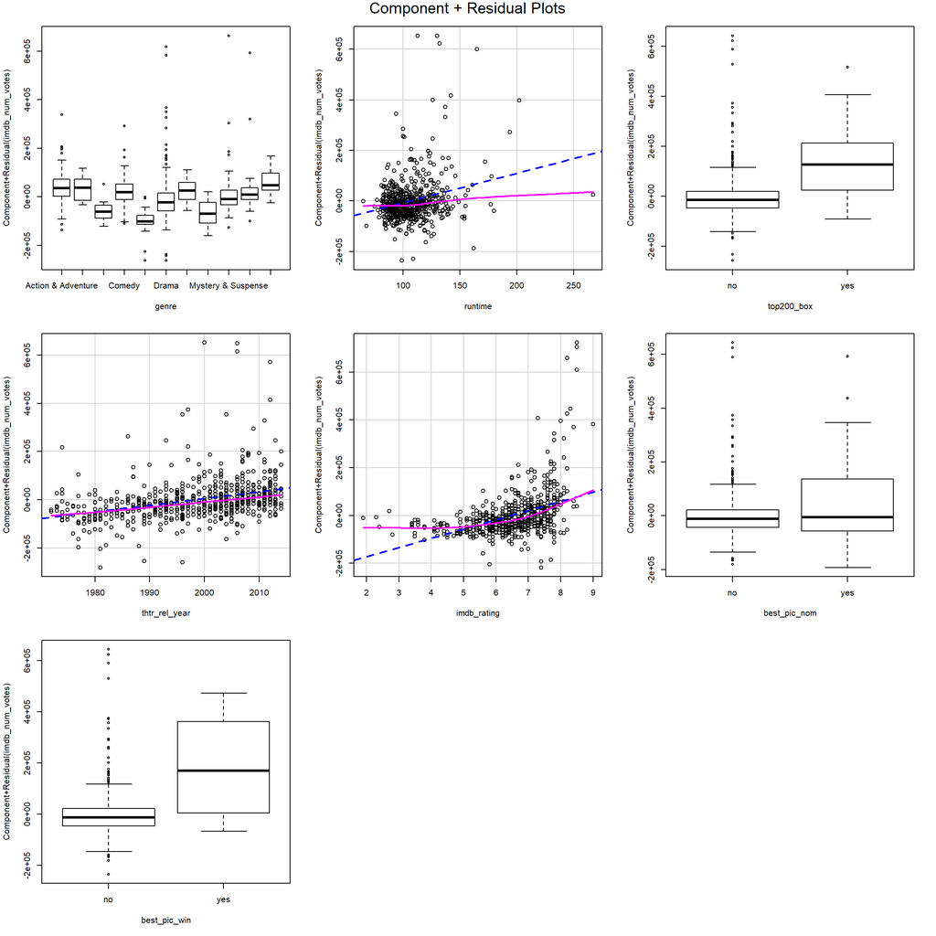

```r
crPlots(all_feats_but_3)
```

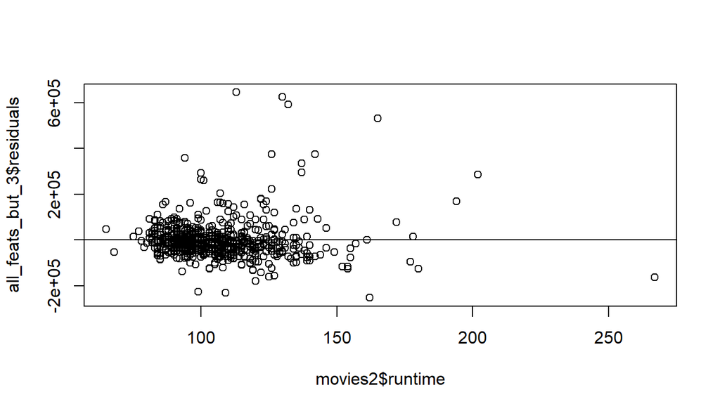

```r
plot(all_feats_but_3$residuals ~ movies2$runtime)
abline(0,0)
```

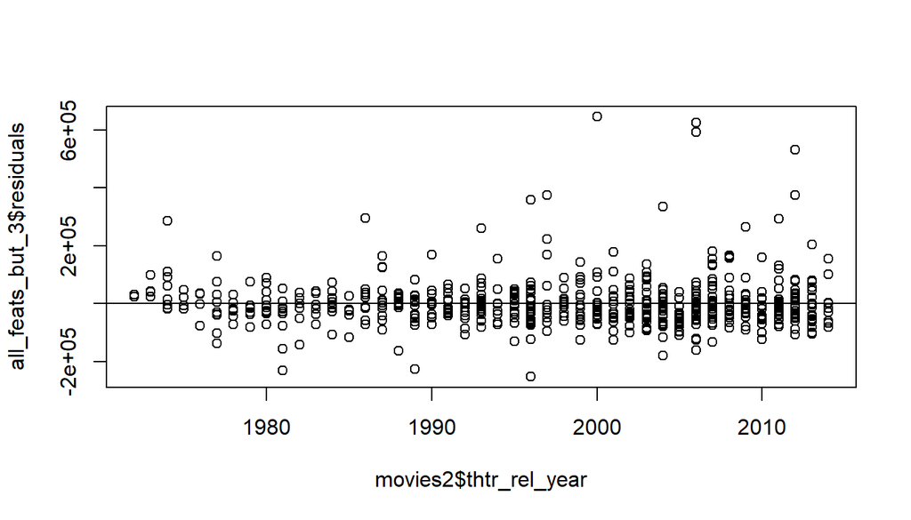

```r
plot(all_feats_but_3$residuals ~ movies2$thtr_rel_year)
abline(0,0)
```

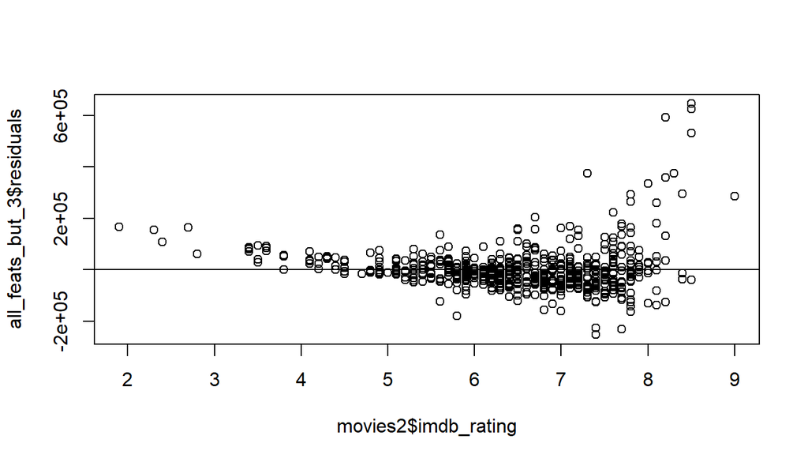

```r
plot(all_feats_but_3$residuals ~ movies2$imdb_rating)
abline(0,0)
```

**Linearity condition:** thtr_rel_year shows an adequate random scatter around 0. runtime and imdb_rating on the otherhand, don’t exhibit slight or no random scatter of variables, rather concentrated around a specific space. Only thtr_rel_year has a strong linear relationship. This might be the reason for the low adjusted R-squared value.

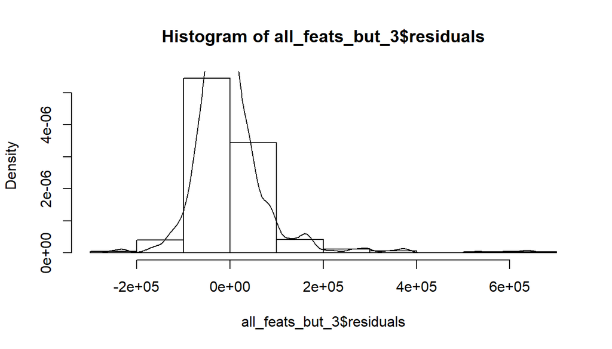

```r
hist(all_feats_but_3$residuals,freq=FALSE)
dens <- density(all_feats_but_3$residuals)
lines(dens)
```

There is a slight right skew but the distribution can qualify as nearly normal.

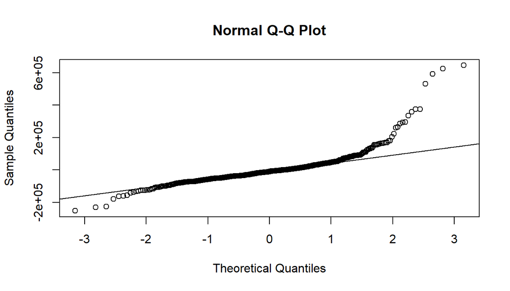

```r
qqnorm(all_feats_but_3$residuals)
qqline(all_feats_but_3$residuals)
```

**Nearly normal residuals around mean 0** Slightly significant deviation from mean is towards the tails. The above plots show that the residuals form a nearly normal distribution of plots centered at 0. This condition is met but not strongly.

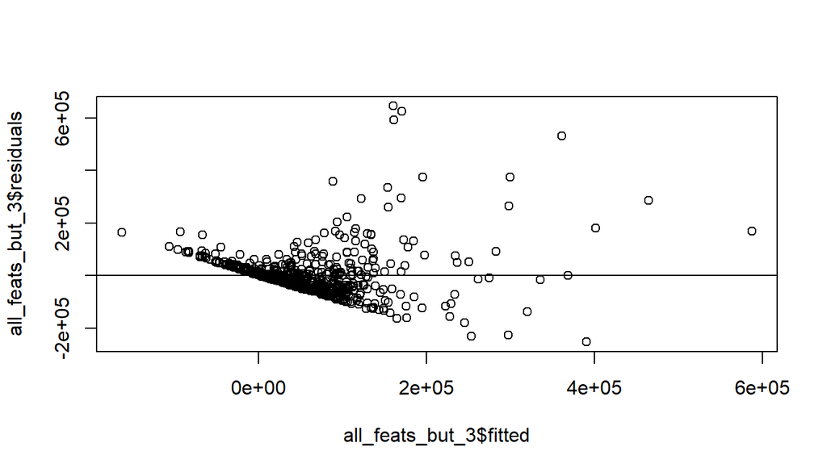

```r
plot(all_feats_but_3$residuals ~ all_feats_but_3$fitted)
abline(0,0)
```

```r
ncvTest(all_feats_but_3)
```

```
## Non-constant Variance Score Test
## Variance formula: ~ fitted.values
## Chisquare = 571.4716, Df = 1, p = < 2.22e-16
```

**Constant variability of residuals:** This condition doesn’t seem to be met here as the scatter is not random and is concentrated at a particular space. ncvTest also gives a very significant p-value which means that there is no constant variance.

```r
durbinWatsonTest(all_feats_but_3)
```

```
##  lag Autocorrelation D-W Statistic p-value
##    1    -0.001243225      2.002306   0.944
##  Alternative hypothesis: rho != 0
```

**Independent residuals:** As p-value form Durbin-Watson test is very high, we can’t reject the null hypothesis and conclude that there is no autocorrelation. Hence, these residuals are independent and the condition is met.

### Model interpretation

$\hat{Number.of.votes.on.imdb}$(imdb_num_votes) = -5860613.5 +  
190043.1 * best_pic_win:yes +  
63044.8 * best_pic_nom:yes +  
38614.7 * imdb_rating +  
2792.4 * thtr_rel_year +  
145096.6 * top200_box:yes +  
1171.8 * runtime +  
19410.9 * genre:Science Fiction & Fantasy +  
18778.5 * genre:Other +  
(-24416.2) * genre:Mystery & Suspense +  
(-109759.7) * genre:Musical & Performing Arts +  
(-16328.8) * genre:Horror +  
(-51219.7) * genre:Drama +  
(-140098.5) * genre:Documentary +  
(-15001.0) * genre:Comedy +  
(-99442.2) * genre:Art House & International +  
(-6862.9) * genre:Animation

  | Genre | Effect |
  | --- | --- |
  | Animation | around 6862 less votes by users |
  | Art House & International | around 99442 less votes by users |
  | Comedy | around 15001 less votes by users |
  | Documentary | around 140098 less votes by users |
  | Drama | around 51219 less votes by users |
  | Horror | around 16328 less votes by users |
  | Musical & Performing Arts | around 109759 less votes by users |
  | Mystery & Suspense | around 24416 less votes by users |
  | Other | around 18778 more votes by users |
  | Science Fiction & Fantasy | around 19410 more votes by users |

## Part 5: Prediction

We will predict the number of votes on IMDb for 21 Jump Street, a comedy film released in 2012.

```r
new.data.point <- data.frame(genre="Comedy",runtime=109,top200_box="no",thtr_rel_year=2012,imdb_rating=7.2,best_pic_nom="no",best_pic_win="no")
predict(all_feats_but_3,new.data.point,interval="prediction",level=0.95)
```

```
##        fit       lwr      upr
## 1 148474.6 -25395.86 322345.1
```

We are 95% confident that number of voters on IMDb for 21 Jump Street are between -25394 and 322345. In 2020, 21 Jump Street has around 491000 votes on IMDb. Our prediction interval doesn’t contain this value even if take maximum release year in the data into account.